# Lithuania trade with Russia

# Introduction

This document gives an overview of Lithuania trade with Russia and its neighbouring countries.

Export to Russia dropped by 35% after Russia invasion of Ukraine on February 24th, 2022. Export to Russia neighbours increased by 101%.

Total export to Russia and neighbouring countries increased by 5.84% from 4.11 billion euros to 4.35 billion euros.

## Overall trade

### Lithuania exports to Russia and neighbouring countries

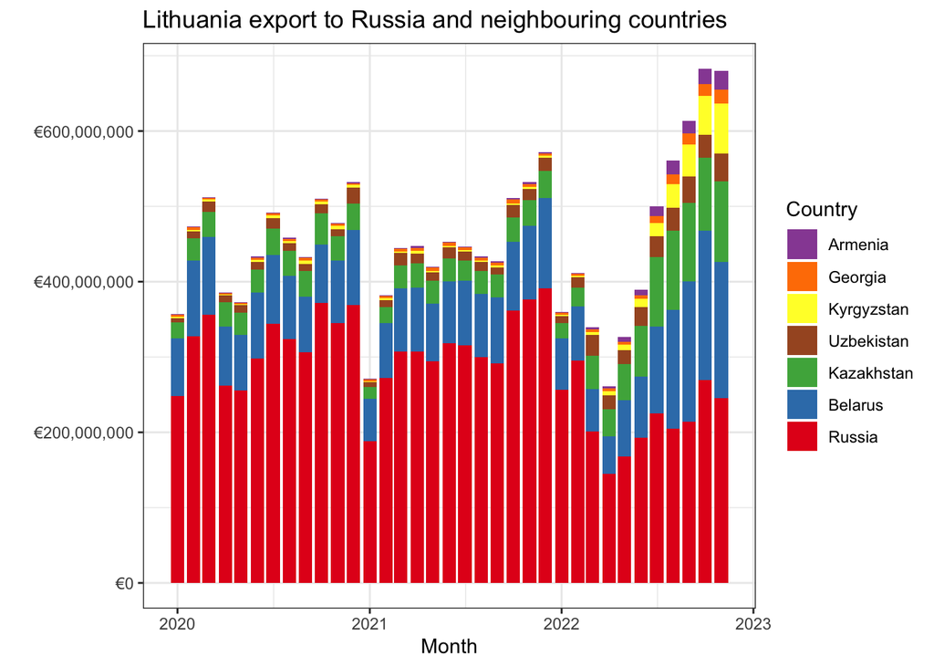

### Lithuania export to Russia neighbours

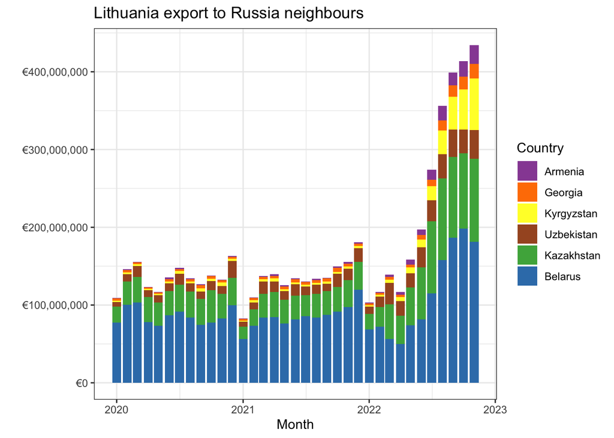

### Lithuania import from Russia and neighbouring countries

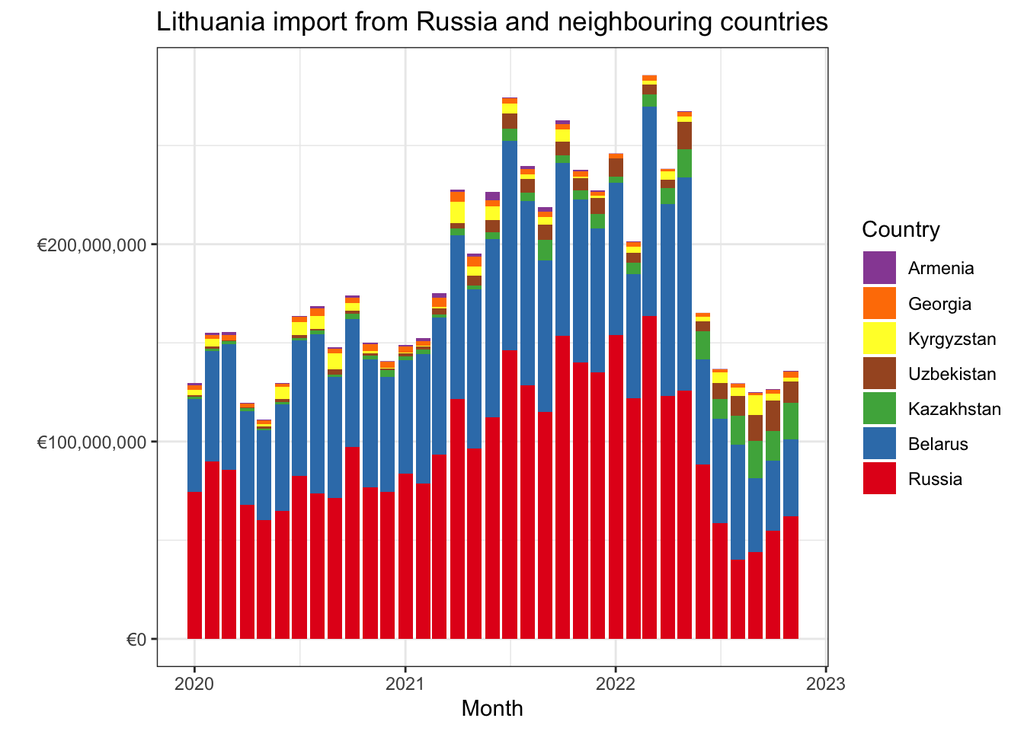

### Lithiania import from Russia neighbours

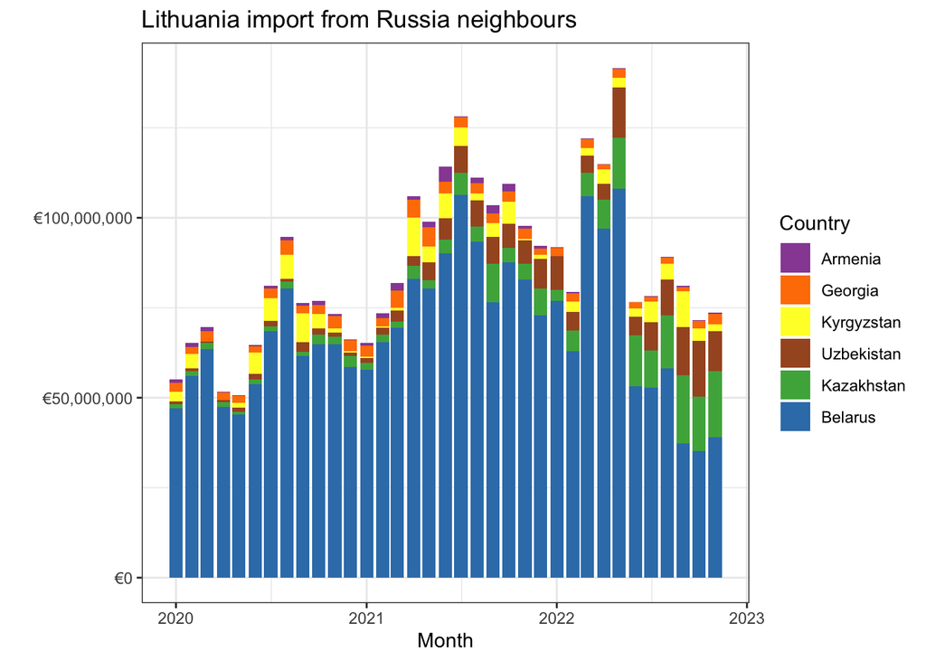

# Effect of sanctions on export

Sanctions put on exports are listed by their CN code in the following [document](https://eur-lex.europa.eu/legal-content/EN/TXT/?uri=CELEX%3A02014R0833-20221007). See Section 3 for technical details how the data was collected. The sanctions mentioned both CN 4 digits and CN 8 digits code. Only CN 8 digit codes were used for analysis.

There are quotas and exceptions for certain sanctioned goods, which allow export, so it is expected that sanctioned export is non zero. The effect of quotas and exceptions is not taken to account.

## Export of sanctioned goods

### To Russia with its neighbours

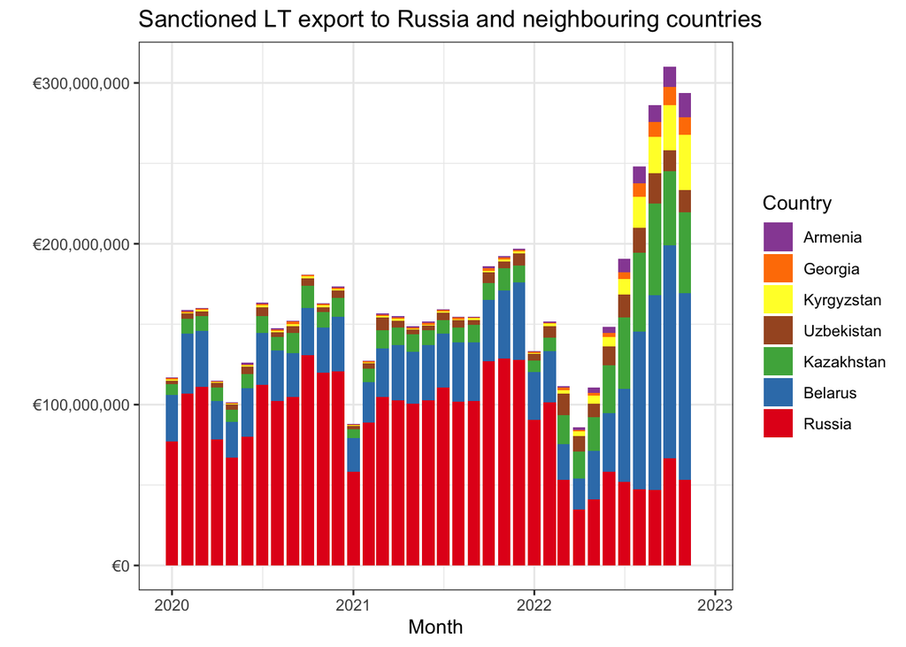

### To Russia neighbours

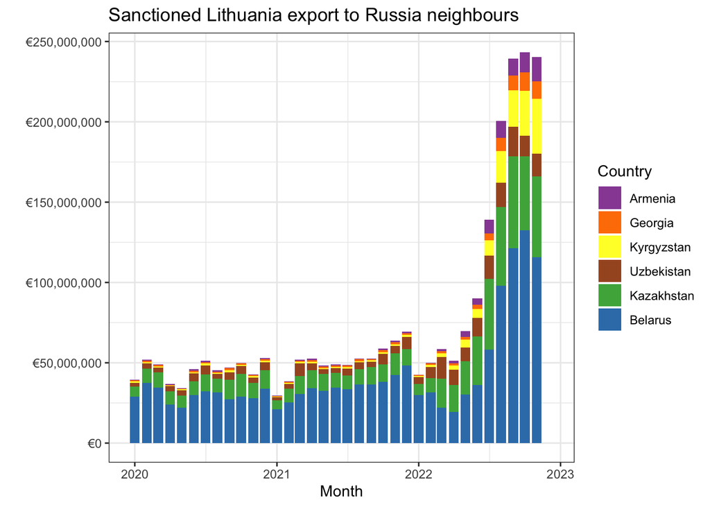

## Sanction anomalies

### Anomalous markets

Define by market an EU country, its export destination and good defined by 8 digit CN classifier.

Using the anomaly definition 160 export categories stand out. It is interesting that there are 21` categories of sanctioned exports to Russia which experienced triple digit growth.

| reporter | partner | code | product | value | growth |
| --- | --- | --- | --- | --- | --- |
| Lithuania | Belarus | 87033290 | Motor cars and other motor vehicles principally designed for the transport of &lt;10 persons, incl. station wagons and racing cars, with only diesel engine of a cylinder capacity &gt; 1.500 cm³ but &l… | 173719591 | 2.1535 |
| Lithuania | Belarus | 87033390 | Motor cars and other motor vehicles principally designed for the transport of &lt;10 persons, incl. station wagons and racing cars, with only diesel engine of a cylinder capacity &gt; 2.500 cm³, used … | 75923299 | 18.1877 |
| Lithuania | Belarus | 87032390 | Motor cars and other motor vehicles principally designed for the transport of &lt;10 persons, incl. station wagons and racing cars, with only spark-ignition internal combustion reciprocating piston en… | 36017706 | 22.9167 |
| Lithuania | Kazakhstan | 87012190 | Road tractors for semi-trailers, with only compression-ignition internal combustion piston engine "diesel or semi-diesel", used | 24823139 |  |
| Lithuania | Armenia | 87089997 | Parts and accessories for tractors, motor vehicles for the transport of ten or more persons, motor cars and other motor vehicles principally designed for the transport of persons, motor vehicles for t… | 24494647 | 4054.4051 |
| Lithuania | Uzbekistan | 87012190 | Road tractors for semi-trailers, with only compression-ignition internal combustion piston engine "diesel or semi-diesel", used | 24369713 |  |
| Lithuania | Uzbekistan | 87163980 | Trailers and semi-trailers for the transport of goods, used (excl. self-loading or self-unloading trailers and semi-trailers for agricultural purposes, tanker trailers and semi-trailers, and trailers … | 23295890 | 1.9871 |
| Lithuania | Belarus | 87032490 | Motor cars and other motor vehicles principally designed for the transport of &lt;10 persons, incl. station wagons and racing cars, with only spark-ignition internal combustion reciprocating piston en… | 19036575 | 146.0006 |
| Lithuania | Belarus | 87035000 | Motor cars and other motor vehicles principally designed for the transport of &lt;10 persons, incl. station wagons and racing cars, with both diesel engine and electric motor as motors for propulsion … | 17195155 | 394.7913 |
| Lithuania | Kazakhstan | 63090000 | Worn clothing and clothing accessories, blankets and travelling rugs, household linen and articles for interior furnishing, of all types of textile materials, incl. all types of footwear and headgear,… | 15416462 | 181.0297 |

[output cut: 150 more lines]

The growth with empty values in the table means that the export in year 2021 from March to November was zero. The full name of exported goods appears if you hover on truncated name.

The full table with all the markets, their after the start of the war export value and growth from the same period in year 2021 can be found [here](https://github.com/vzemlys/ruimpeks/tree/main/xlsx/eu_sanctioned_export_growth.xlsx). Note the file size is 11MB.

# Appendix

## Data

The data used comes from Eurostat dataset on international trade in [goods](https://ec.europa.eu/eurostat/databrowser/view/DS-045409/legacyMultiFreq/table?lang=en).

All the code and data resides in the [Github repository](https://github.com/vzemlys/ruimpeks/):

1. [Code for this document](https://github.com/vzemlys/ruimpeks/blob/main/eu_ru_trade.qmd).
2. [Total trade data](https://github.com/vzemlys/ruimpeks/tree/main/xlsx).
3. [CN codes for export sanctions](https://github.com/vzemlys/ruimpeks/blob/main/raw/input_codes.csv).
4. [Sanctioned export data](https://github.com/vzemlys/ruimpeks/tree/main/raw) and the [code to prepare it](https://github.com/vzemlys/ruimpeks/blob/main/R/prepare_data.R).
5. [Sanctioned exports CN 8 digits codes](https://github.com/vzemlys/ruimpeks/blob/main/meta/export_sanctions_codes.csv).